# MODEL BUILDING

## Model Building using Random Forests

- Filter the dataset for good weather data as all the flights on bad weather are delayed
- Divide the schedule time into equal intervals for better accuracy
- Filter the dataset for ontime flights
- Take the random data of ontime flights and concatenate it with delayed flights data
- Divide the data into train and test
- Fit the model
- Train and Test the data

```python
from sklearn.metrics import roc_auc_score
import pandas as pd
from sklearn import preprocessing
import numpy as np
from sklearn.metrics import roc_curve, auc
import matplotlib.pyplot as plt

le = preprocessing.LabelEncoder()
data=pd.read_csv("C:\\Users\\mnr\\Downloads\\FlightDelays.csv")
data=data.reset_index()
data.head()

def describe_categorical(X):
    from IPython.display import display,HTML
    display (HTML(X[X.columns[X.dtypes=='object']].describe().to_html()))
```

```python
DATA=data[data.weather==0]
DATA.head()
```

|  | index | sno | schedtime | carrier | deptime | dest | distance | date | flightnumber | origin | weather | dayweek | daymonth | tailnu | delay |
| --- | --- | --- | --- | --- | --- | --- | --- | --- | --- | --- | --- | --- | --- | --- | --- |
| 0 | 0 | 1 | 1455 | OH | 1455 | JFK | 184 | 1/1/2004 | 5935 | BWI | 0 | 4 | 1 | N940CA | ontime |
| 1 | 1 | 2 | 1640 | DH | 1640 | JFK | 213 | 1/1/2004 | 6155 | DCA | 0 | 4 | 1 | N405FJ | ontime |
| 2 | 2 | 3 | 1245 | DH | 1245 | LGA | 229 | 1/1/2004 | 7208 | IAD | 0 | 4 | 1 | N695BR | ontime |
| 3 | 3 | 4 | 1715 | DH | 1709 | LGA | 229 | 1/1/2004 | 7215 | IAD | 0 | 4 | 1 | N662BR | ontime |
| 4 | 4 | 5 | 1039 | DH | 1035 | LGA | 229 | 1/1/2004 | 7792 | IAD | 0 | 4 | 1 | N698BR | ontime |

```python
DATA.describe()
```

|  | index | sno | schedtime | deptime | distance | flightnumber | weather | dayweek | daymonth |
| --- | --- | --- | --- | --- | --- | --- | --- | --- | --- |
| count | 2169.000000 | 2169.000000 | 2169.000000 | 2169.000000 | 2169.000000 | 2169.000000 | 2169.0 | 2169.000000 | 2169.000000 |
| mean | 1088.995390 | 1089.995390 | 1372.372983 | 1368.278008 | 211.817888 | 3802.773628 | 0.0 | 3.934071 | 15.873213 |
| std | 633.480502 | 633.480502 | 432.672586 | 442.363020 | 13.325077 | 2405.983555 | 0.0 | 1.893567 | 8.647572 |
| min | 0.000000 | 1.000000 | 600.000000 | 10.000000 | 169.000000 | 746.000000 | 0.0 | 1.000000 | 1.000000 |
| 25% | 542.000000 | 543.000000 | 1000.000000 | 1004.000000 | 213.000000 | 2156.000000 | 0.0 | 2.000000 | 8.000000 |
| 50% | 1084.000000 | 1085.000000 | 1455.000000 | 1450.000000 | 214.000000 | 2385.000000 | 0.0 | 4.000000 | 16.000000 |
| 75% | 1627.000000 | 1628.000000 | 1710.000000 | 1709.000000 | 214.000000 | 5935.000000 | 0.0 | 5.000000 | 23.000000 |
| max | 2200.000000 | 2201.000000 | 2130.000000 | 2330.000000 | 229.000000 | 7924.000000 | 0.0 | 7.000000 | 31.000000 |

```python
describe_categorical(DATA)
```

|  | carrier | dest | date | origin | tailnu | delay |
| --- | --- | --- | --- | --- | --- | --- |
| count | 2169 | 2169 | 2169 | 2169 | 2169 | 2169 |
| unique | 8 | 3 | 31 | 3 | 543 | 2 |
| top | DH | LGA | 1/22/2004 | DCA | N225DL | ontime |
| freq | 540 | 1134 | 86 | 1353 | 63 | 1773 |

## Time intervals

- Convert the schedule time(int) into Time(datetime)
- Split the time into equal intervals of day

```python
DATA['datetime']=pd.to_datetime(DATA['schedtime'],unit='h')
DATA2=DATA['datetime'].reset_index()
#data2
DATA['time'] = DATA.datetime.dt.time
DATA['time_hour'] = DATA.time.apply(lambda x: x.hour)
DATA['Time_interval'] = pd.cut(DATA['time_hour'], [0, 6, 12,18,24], labels=['early_morning', 'mid_morning', 'evening','night'])
DATA.head()
```

|  | index | sno | schedtime | carrier | deptime | dest | distance | date | flightnumber | origin | weather | dayweek | daymonth | tailnu | delay | datetime | time | time_hour | Time_interval |
| --- | --- | --- | --- | --- | --- | --- | --- | --- | --- | --- | --- | --- | --- | --- | --- | --- | --- | --- | --- |
| 0 | 0 | 1 | 1455 | OH | 1455 | JFK | 184 | 1/1/2004 | 5935 | BWI | 0 | 4 | 1 | N940CA | ontime | 1970-03-02 15:00:00 | 15:00:00 | 15 | evening |
| 1 | 1 | 2 | 1640 | DH | 1640 | JFK | 213 | 1/1/2004 | 6155 | DCA | 0 | 4 | 1 | N405FJ | ontime | 1970-03-10 08:00:00 | 08:00:00 | 8 | mid_morning |
| 2 | 2 | 3 | 1245 | DH | 1245 | LGA | 229 | 1/1/2004 | 7208 | IAD | 0 | 4 | 1 | N695BR | ontime | 1970-02-21 21:00:00 | 21:00:00 | 21 | night |
| 3 | 3 | 4 | 1715 | DH | 1709 | LGA | 229 | 1/1/2004 | 7215 | IAD | 0 | 4 | 1 | N662BR | ontime | 1970-03-13 11:00:00 | 11:00:00 | 11 | mid_morning |
| 4 | 4 | 5 | 1039 | DH | 1035 | LGA | 229 | 1/1/2004 | 7792 | IAD | 0 | 4 | 1 | N698BR | ontime | 1970-02-13 07:00:00 | 07:00:00 | 7 | mid_morning |

## Random Samples of Ontime data

- Filter the delay column and get the Ontime flights data
- Take the random sample from the ontime data
- Dividing the data into 5 random samples to build multiple models for greater accuracy
- Filter the delay column for delayed data
- Concatenate the random ontime data and delayed data

```python
DATA_O=DATA[DATA.delay=='ontime']
DATA_O.head()
```

|  | index | sno | schedtime | carrier | deptime | dest | distance | date | flightnumber | origin | weather | dayweek | daymonth | tailnu | delay | datetime | time | time_hour | Time_interval |
| --- | --- | --- | --- | --- | --- | --- | --- | --- | --- | --- | --- | --- | --- | --- | --- | --- | --- | --- | --- |
| 0 | 0 | 1 | 1455 | OH | 1455 | JFK | 184 | 1/1/2004 | 5935 | BWI | 0 | 4 | 1 | N940CA | ontime | 1970-03-02 15:00:00 | 15:00:00 | 15 | evening |
| 1 | 1 | 2 | 1640 | DH | 1640 | JFK | 213 | 1/1/2004 | 6155 | DCA | 0 | 4 | 1 | N405FJ | ontime | 1970-03-10 08:00:00 | 08:00:00 | 8 | mid_morning |
| 2 | 2 | 3 | 1245 | DH | 1245 | LGA | 229 | 1/1/2004 | 7208 | IAD | 0 | 4 | 1 | N695BR | ontime | 1970-02-21 21:00:00 | 21:00:00 | 21 | night |
| 3 | 3 | 4 | 1715 | DH | 1709 | LGA | 229 | 1/1/2004 | 7215 | IAD | 0 | 4 | 1 | N662BR | ontime | 1970-03-13 11:00:00 | 11:00:00 | 11 | mid_morning |
| 4 | 4 | 5 | 1039 | DH | 1035 | LGA | 229 | 1/1/2004 | 7792 | IAD | 0 | 4 | 1 | N698BR | ontime | 1970-02-13 07:00:00 | 07:00:00 | 7 | mid_morning |

```python
DATA_R1 = DATA_O.sample(n=400)
DATA_R2 = DATA_O.sample(n=400)
DATA_R3 = DATA_O.sample(n=400)
DATA_R4 = DATA_O.sample(n=400)
DATA_R5 = DATA_O.sample(n=400)
```

```python
DATA_D=DATA[DATA.delay=='delayed']
DATA_D.head()
DATA_D.shape
```

```
(396, 19)
```

```python
DATA_NEW1=pd.concat([DATA_R1,DATA_D])
DATA_NEW2=pd.concat([DATA_R2,DATA_D])
DATA_NEW3=pd.concat([DATA_R3,DATA_D])
DATA_NEW4=pd.concat([DATA_R4,DATA_D])
DATA_NEW5=pd.concat([DATA_R5,DATA_D])
#print(DATA_NEW.head())
DATA_NEW5.shape
DATA_NEW5.head()
```

|  | index | sno | schedtime | carrier | deptime | dest | distance | date | flightnumber | origin | weather | dayweek | daymonth | tailnu | delay | datetime | time | time_hour | Time_interval |
| --- | --- | --- | --- | --- | --- | --- | --- | --- | --- | --- | --- | --- | --- | --- | --- | --- | --- | --- | --- |
| 1264 | 1264 | 1265 | 930 | RU | 925 | EWR | 199 | 1/18/2004 | 2582 | DCA | 0 | 7 | 18 | N27962 | ontime | 1970-02-08 18:00:00 | 18:00:00 | 18 | evening |
| 1343 | 1343 | 1344 | 1359 | RU | 1355 | EWR | 199 | 1/19/2004 | 2216 | DCA | 0 | 1 | 19 | N12519 | ontime | 1970-02-26 15:00:00 | 15:00:00 | 15 | evening |
| 965 | 965 | 966 | 1300 | MQ | 1255 | LGA | 214 | 1/14/2004 | 4964 | DCA | 0 | 3 | 14 | N724MQ | ontime | 1970-02-24 04:00:00 | 04:00:00 | 4 | early_morning |
| 871 | 871 | 872 | 1930 | DL | 1930 | LGA | 214 | 1/13/2004 | 1766 | DCA | 0 | 2 | 13 | N221DL | ontime | 1970-03-22 10:00:00 | 10:00:00 | 10 | mid_morning |
| 1615 | 1615 | 1616 | 1610 | DH | 1609 | JFK | 228 | 1/23/2004 | 7816 | IAD | 0 | 5 | 23 | N332UE | ontime | 1970-03-09 02:00:00 | 02:00:00 | 2 | early_morning |

## Drop Unnecessary columns

- The features used to build a model should be of integer datatype
- The target variable i.e delay(str) is converted to integer
- The columns which are not required are dropped from the dataset

```python
DATA_NEW1['delay'] = le.fit_transform(DATA_NEW1['delay'])
DATA_NEW2['delay'] = le.fit_transform(DATA_NEW2['delay'])
DATA_NEW3['delay'] = le.fit_transform(DATA_NEW3['delay'])
DATA_NEW4['delay'] = le.fit_transform(DATA_NEW4['delay'])
DATA_NEW5['delay'] = le.fit_transform(DATA_NEW5['delay'])
```

```python
DATA_NEW1.drop(['index','sno','schedtime','deptime','date','flightnumber','daymonth','tailnu','datetime','time','time_hour'], axis= 1 ,inplace=True)
DATA_NEW2.drop(['index','sno','schedtime','deptime','date','flightnumber','daymonth','tailnu','datetime','time','time_hour'], axis= 1 ,inplace=True)
DATA_NEW3.drop(['index','sno','schedtime','deptime','date','flightnumber','daymonth','tailnu','datetime','time','time_hour'], axis= 1 ,inplace=True)
DATA_NEW4.drop(['index','sno','schedtime','deptime','date','flightnumber','daymonth','tailnu','datetime','time','time_hour'], axis= 1 ,inplace=True)
DATA_NEW5.drop(['index','sno','schedtime','deptime','date','flightnumber','daymonth','tailnu','datetime','time','time_hour'], axis= 1 ,inplace=True)
```

## MODEL 1

### Categorical variables

- Create the dummy variables for the categorical variables
- As the data to build a model should be of integer datatype,we use dummy variables
- After creating dummy variables,we drop the categorical variable columns

```python
categorical_variables=['carrier','dest','origin','dayweek','Time_interval']
for variable in categorical_variables:
#     X[variable].fillna("Missing",inplace=True)
    dummies=pd.get_dummies(DATA_NEW1[variable],prefix=variable)
    DATA_NEW1=pd.concat([DATA_NEW1,dummies],axis=1)
    DATA_NEW1.drop([variable],axis=1,inplace=True)

DATA_NEW1.head()
```

|  | distance | weather | delay | carrier_CO | carrier_DH | carrier_DL | carrier_MQ | carrier_OH | carrier_RU | carrier_UA | ... | dayweek_2 | dayweek_3 | dayweek_4 | dayweek_5 | dayweek_6 | dayweek_7 | Time_interval_early_morning | Time_interval_mid_morning | Time_interval_evening | Time_interval_night |
| --- | --- | --- | --- | --- | --- | --- | --- | --- | --- | --- | --- | --- | --- | --- | --- | --- | --- | --- | --- | --- | --- |
| 617 | 169 | 0 | 1 | 0 | 0 | 0 | 0 | 0 | 1 | 0 | ... | 0 | 0 | 0 | 1 | 0 | 0 | 0 | 0 | 1 | 0 |
| 1680 | 213 | 0 | 1 | 0 | 0 | 0 | 0 | 0 | 1 | 0 | ... | 0 | 0 | 0 | 1 | 0 | 0 | 0 | 0 | 0 | 1 |
| 2182 | 214 | 0 | 1 | 0 | 0 | 0 | 0 | 0 | 0 | 0 | ... | 0 | 0 | 0 | 0 | 1 | 0 | 0 | 0 | 0 | 1 |
| 672 | 214 | 0 | 1 | 0 | 0 | 0 | 0 | 0 | 0 | 0 | ... | 0 | 0 | 0 | 0 | 1 | 0 | 0 | 0 | 0 | 1 |
| 924 | 199 | 0 | 1 | 0 | 0 | 0 | 0 | 0 | 1 | 0 | ... | 1 | 0 | 0 | 0 | 0 | 0 | 0 | 0 | 0 | 1 |

5 rows × 28 columns

### Split the data into train and test

```python
# Using Skicit-learn to split data into training and testing sets
from sklearn.model_selection import train_test_split
# Split the data into training and testing sets
Train_Features1, Test_Features1, Train_Labels1, Test_Labels1 = train_test_split(DATA_NEW1,DATA_NEW1['delay'],test_size = 0.25, random_state = 42)
```

```python
print('Training Features Shape:',Train_Features1.shape)
print('Training Labels Shape:', Train_Labels1.shape)
print('Testing Features Shape:', Test_Features1.shape)
print('Testing Labels Shape:', Test_Labels1.shape)
```

```
Training Features Shape: (597, 28)
Training Labels Shape: (597,)
Testing Features Shape: (199, 28)
Testing Labels Shape: (199,)
```

```python
def printall(DATA_NEW1,max_rows=10):
    from IPython.display import display,HTML
    display(HTML(DATA_NEW1.to_html(max_rows=max_rows)))

printall(DATA_NEW1.head())
DATA_NEW1.shape
```

|  | distance | weather | delay | carrier_CO | carrier_DH | carrier_DL | carrier_MQ | carrier_OH | carrier_RU | carrier_UA | carrier_US | dest_EWR | dest_JFK | dest_LGA | origin_BWI | origin_DCA | origin_IAD | dayweek_1 | dayweek_2 | dayweek_3 | dayweek_4 | dayweek_5 | dayweek_6 | dayweek_7 | Time_interval_early_morning | Time_interval_mid_morning | Time_interval_evening | Time_interval_night |
| --- | --- | --- | --- | --- | --- | --- | --- | --- | --- | --- | --- | --- | --- | --- | --- | --- | --- | --- | --- | --- | --- | --- | --- | --- | --- | --- | --- | --- |
| 617 | 169 | 0 | 1 | 0 | 0 | 0 | 0 | 0 | 1 | 0 | 0 | 1 | 0 | 0 | 1 | 0 | 0 | 0 | 0 | 0 | 0 | 1 | 0 | 0 | 0 | 0 | 1 | 0 |
| 1680 | 213 | 0 | 1 | 0 | 0 | 0 | 0 | 0 | 1 | 0 | 0 | 1 | 0 | 0 | 0 | 0 | 1 | 0 | 0 | 0 | 0 | 1 | 0 | 0 | 0 | 0 | 0 | 1 |
| 2182 | 214 | 0 | 1 | 0 | 0 | 0 | 0 | 0 | 0 | 0 | 1 | 0 | 0 | 1 | 0 | 1 | 0 | 0 | 0 | 0 | 0 | 0 | 1 | 0 | 0 | 0 | 0 | 1 |
| 672 | 214 | 0 | 1 | 0 | 0 | 0 | 0 | 0 | 0 | 0 | 1 | 0 | 0 | 1 | 0 | 1 | 0 | 0 | 0 | 0 | 0 | 0 | 1 | 0 | 0 | 0 | 0 | 1 |
| 924 | 199 | 0 | 1 | 0 | 0 | 0 | 0 | 0 | 1 | 0 | 0 | 1 | 0 | 0 | 0 | 1 | 0 | 0 | 1 | 0 | 0 | 0 | 0 | 0 | 0 | 0 | 0 | 1 |

```
(796, 28)
```

```python
predictors1  = [ x for x in Train_Features1.columns if x not in ['delay']]
target1 = 'delay'
```

### Fit the model

```python
from sklearn.ensemble import RandomForestClassifier
model1=RandomForestClassifier(100,oob_score=True,n_jobs=-1,random_state=42)
#Y=X['delay']
model1.fit(Train_Features1[predictors1],Train_Features1[target1])
```

```
RandomForestClassifier(bootstrap=True, class_weight=None, criterion='gini',
            max_depth=None, max_features='auto', max_leaf_nodes=None,
            min_impurity_decrease=0.0, min_impurity_split=None,
            min_samples_leaf=1, min_samples_split=2,
            min_weight_fraction_leaf=0.0, n_estimators=100, n_jobs=-1,
            oob_score=True, random_state=42, verbose=0, warm_start=False)
```

```python
Test_predictors1 = model1.predict(Test_Features1[predictors1])
Test_Features1['Predicted'] = Test_predictors1
Test_Features1[['delay','Predicted']].head()
```

|  | delay | Predicted |
| --- | --- | --- |
| 1706 | 0 | 1 |
| 2064 | 0 | 1 |
| 1095 | 1 | 1 |
| 856 | 0 | 0 |
| 69 | 1 | 1 |

### Confusion matrix

```python
y_actu1 = pd.Series(Test_Features1['delay'], name='Actual')
y_pred1 = pd.Series(Test_Features1['Predicted'], name='Predicted')
df_confusion1 = pd.crosstab(y_actu1, y_pred1)
df_confusion1 = pd.crosstab(y_actu1, y_pred1, rownames=['Actual'], colnames=['Predicted'], margins=True)
df_confusion1
```

| Predicted Actual | 0 | 1 | All |
| --- | --- | --- | --- |
| 0 | 70 | 32 | 102 |
| 1 | 35 | 62 | 97 |
| All | 105 | 94 | 199 |

### Accuracy score

```python
from sklearn.metrics import accuracy_score
AVG1=accuracy_score(y_actu1,y_pred1)

print('accuracy score:',AVG1)
```

```
accuracy score: 0.6633165829145728
```

```python
ROC_AUC1=roc_auc_score(y_actu1, y_pred1, average=None, sample_weight=None)
```

### ROC_AUC curve

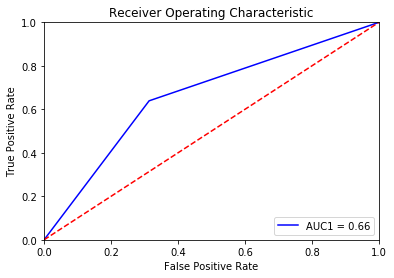

```python
from sklearn import metrics
fpr, tpr, threshold = metrics.roc_curve(y_actu1, y_pred1)
roc_auc1= metrics.auc(fpr, tpr)


import matplotlib.pyplot as plt
plt.title('Receiver Operating Characteristic')
plt.plot(fpr, tpr, 'b', label = 'AUC1 = %0.2f' % roc_auc1)
AUC1=roc_auc1
#print(AUC1)
plt.legend(loc = 'lower right')
plt.plot([0, 1], [0, 1],'r--')
plt.xlim([0, 1])
plt.ylim([0, 1])
plt.ylabel('True Positive Rate')
plt.xlabel('False Positive Rate')
plt.show()
```

### Feature Importances

```python
model1.feature_importances_
```

```
array([0.06024299, 0.        , 0.00642639, 0.02285042, 0.03298179,
       0.03122835, 0.00371738, 0.01903073, 0.00434588, 0.02962967,
       0.01644644, 0.02461385, 0.02544618, 0.01059491, 0.02525046,
       0.0147951 , 0.05413787, 0.05382366, 0.05978054, 0.07244177,
       0.06070519, 0.04885558, 0.05873835, 0.07111589, 0.06532922,
       0.06949993, 0.05797149])
```

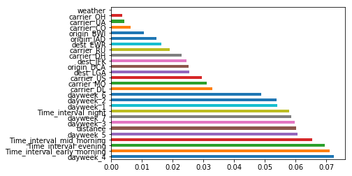

```python
feat_importances1 = pd.Series(model1.feature_importances_, index=Train_Features1[predictors1].columns)
feat_importances1 = feat_importances1.nlargest(28)
feat_importances1.plot(kind='barh')
plt.show()
```

## MODEL 2

### Categorical variables

- Create the dummy variables for the categorical variables
- As the data to build a model should be of integer datatype,we use dummy variables
- After creating dummy variables,we drop the categorical variable columns

```python
categorical_variables=['carrier','dest','origin','dayweek','Time_interval']
for variable in categorical_variables:
#     X[variable].fillna("Missing",inplace=True)
    dummies=pd.get_dummies(DATA_NEW2[variable],prefix=variable)
    DATA_NEW2=pd.concat([DATA_NEW2,dummies],axis=1)
    DATA_NEW2.drop([variable],axis=1,inplace=True)

DATA_NEW2.head()
```

|  | distance | weather | delay | carrier_CO | carrier_DH | carrier_DL | carrier_MQ | carrier_OH | carrier_RU | carrier_UA | ... | dayweek_2 | dayweek_3 | dayweek_4 | dayweek_5 | dayweek_6 | dayweek_7 | Time_interval_early_morning | Time_interval_mid_morning | Time_interval_evening | Time_interval_night |
| --- | --- | --- | --- | --- | --- | --- | --- | --- | --- | --- | --- | --- | --- | --- | --- | --- | --- | --- | --- | --- | --- |
| 1701 | 214 | 0 | 1 | 0 | 0 | 1 | 0 | 0 | 0 | 0 | ... | 0 | 0 | 0 | 0 | 1 | 0 | 1 | 0 | 0 | 0 |
| 1037 | 213 | 0 | 1 | 0 | 0 | 0 | 1 | 0 | 0 | 0 | ... | 0 | 0 | 1 | 0 | 0 | 0 | 0 | 0 | 1 | 0 |
| 1629 | 214 | 0 | 1 | 0 | 0 | 1 | 0 | 0 | 0 | 0 | ... | 0 | 0 | 0 | 1 | 0 | 0 | 0 | 1 | 0 | 0 |
| 1368 | 214 | 0 | 1 | 0 | 0 | 1 | 0 | 0 | 0 | 0 | ... | 1 | 0 | 0 | 0 | 0 | 0 | 1 | 0 | 0 | 0 |
| 1405 | 214 | 0 | 1 | 0 | 0 | 0 | 0 | 0 | 0 | 0 | ... | 1 | 0 | 0 | 0 | 0 | 0 | 0 | 1 | 0 | 0 |

5 rows × 28 columns

### Train and Test the data

```python
# Using Skicit-learn to split data into training and testing sets
from sklearn.model_selection import train_test_split
# Split the data into training and testing sets
Train_Features2, Test_Features2, Train_Labels2, Test_Labels2 = train_test_split(DATA_NEW2,DATA_NEW2['delay'],test_size = 0.25, random_state = 42)
```

```python
print('Training Features Shape:',Train_Features2.shape)
print('Training Labels Shape:', Train_Labels2.shape)
print('Testing Features Shape:', Test_Features2.shape)
print('Testing Labels Shape:', Test_Labels2.shape)
```

```
Training Features Shape: (597, 28)
Training Labels Shape: (597,)
Testing Features Shape: (199, 28)
Testing Labels Shape: (199,)
```

```python
def printall(DATA_NEW2,max_rows=10):
    from IPython.display import display,HTML
    display(HTML(DATA_NEW2.to_html(max_rows=max_rows)))

printall(DATA_NEW2.head())
DATA_NEW2.shape
```

[output not shown]

[output not shown]

```python
predictors2  = [ x for x in Train_Features2.columns if x not in ['delay']]
target2 = 'delay'
```

## Fit the model

```python
from sklearn.ensemble import RandomForestClassifier
model2=RandomForestClassifier(100,oob_score=True,n_jobs=-1,random_state=42)
#Y=X['delay']
model2.fit(Train_Features2[predictors2],Train_Features2[target2])
```

```
RandomForestClassifier(bootstrap=True, class_weight=None, criterion='gini',
            max_depth=None, max_features='auto', max_leaf_nodes=None,
            min_impurity_decrease=0.0, min_impurity_split=None,
            min_samples_leaf=1, min_samples_split=2,
            min_weight_fraction_leaf=0.0, n_estimators=100, n_jobs=-1,
            oob_score=True, random_state=42, verbose=0, warm_start=False)
```

```python
Test_predictors2 = model2.predict(Test_Features2[predictors2])
Test_Features2['Predicted'] = Test_predictors2
Test_Features2[['delay','Predicted']].head()
```

|  | delay | Predicted |
| --- | --- | --- |
| 1706 | 0 | 1 |
| 2064 | 0 | 0 |
| 718 | 1 | 0 |
| 856 | 0 | 1 |
| 855 | 1 | 0 |

## Confusion matrix

```python
y_actu2 = pd.Series(Test_Features2['delay'], name='Actual')
y_pred2 = pd.Series(Test_Features2['Predicted'], name='Predicted')
df_confusion2 = pd.crosstab(y_actu2, y_pred2)
df_confusion2 = pd.crosstab(y_actu2, y_pred2, rownames=['Actual'], colnames=['Predicted'], margins=True)
df_confusion2
```

| Predicted Actual | 0 | 1 | All |
| --- | --- | --- | --- |
| 0 | 65 | 37 | 102 |
| 1 | 49 | 48 | 97 |
| All | 114 | 85 | 199 |

## Accuracy Score

```python
from sklearn.metrics import accuracy_score
AVG2=accuracy_score(y_actu2,y_pred2)

print('accuracy score:',AVG2)
```

```
accuracy score: 0.5678391959798995
```

```python
ROC_AUC2=roc_auc_score(y_actu2, y_pred2, average=None, sample_weight=None)
```

## ROC_AUC curve

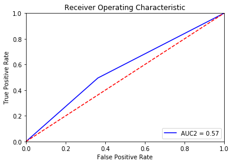

```python
from sklearn import metrics
fpr, tpr, threshold = metrics.roc_curve(y_actu2, y_pred2)
roc_auc2 = metrics.auc(fpr, tpr)


import matplotlib.pyplot as plt
plt.title('Receiver Operating Characteristic')
plt.plot(fpr, tpr, 'b', label = 'AUC2 = %0.2f' % roc_auc2)
AUC2=roc_auc2
plt.legend(loc = 'lower right')
plt.plot([0, 1], [0, 1],'r--')
plt.xlim([0, 1])
plt.ylim([0, 1])
plt.ylabel('True Positive Rate')
plt.xlabel('False Positive Rate')
plt.show()
```

## Feature Importances

```python
model2.feature_importances_
```

```
array([0.06343024, 0.        , 0.01405062, 0.02759145, 0.03117542,
       0.04016399, 0.00245389, 0.01895415, 0.00922757, 0.03989593,
       0.01404608, 0.02394759, 0.02479904, 0.0101593 , 0.02634433,
       0.01510339, 0.05225639, 0.04506767, 0.05508712, 0.06468787,
       0.05957855, 0.0586942 , 0.05208634, 0.06741199, 0.06275508,
       0.06946397, 0.05156782])
```

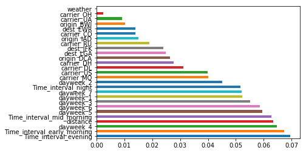

```python
feat_importances2 = pd.Series(model2.feature_importances_, index=Train_Features2[predictors2].columns)
feat_importances2 = feat_importances2.nlargest(28)
feat_importances2.plot(kind='barh')
plt.show()
```

## MODEL 3

### Categorical variables

- Create the dummy variables for the categorical variables
- As the data to build a model should be of integer datatype,we use dummy variables
- After creating dummy variables,we drop the categorical variable columns

```python
categorical_variables=['carrier','dest','origin','dayweek','Time_interval']
for variable in categorical_variables:
#     X[variable].fillna("Missing",inplace=True)
    dummies=pd.get_dummies(DATA_NEW3[variable],prefix=variable)
    DATA_NEW3=pd.concat([DATA_NEW3,dummies],axis=1)
    DATA_NEW3.drop([variable],axis=1,inplace=True)

DATA_NEW3.head()
```

|  | distance | weather | delay | carrier_CO | carrier_DH | carrier_DL | carrier_MQ | carrier_OH | carrier_RU | carrier_UA | ... | dayweek_2 | dayweek_3 | dayweek_4 | dayweek_5 | dayweek_6 | dayweek_7 | Time_interval_early_morning | Time_interval_mid_morning | Time_interval_evening | Time_interval_night |
| --- | --- | --- | --- | --- | --- | --- | --- | --- | --- | --- | --- | --- | --- | --- | --- | --- | --- | --- | --- | --- | --- |
| 820 | 169 | 0 | 1 | 0 | 0 | 0 | 0 | 0 | 1 | 0 | ... | 0 | 0 | 0 | 0 | 0 | 0 | 0 | 0 | 1 | 0 |
| 680 | 213 | 0 | 1 | 0 | 1 | 0 | 0 | 0 | 0 | 0 | ... | 0 | 0 | 0 | 0 | 1 | 0 | 1 | 0 | 0 | 0 |
| 1528 | 228 | 0 | 1 | 0 | 1 | 0 | 0 | 0 | 0 | 0 | ... | 0 | 0 | 1 | 0 | 0 | 0 | 0 | 1 | 0 | 0 |
| 78 | 214 | 0 | 1 | 0 | 0 | 0 | 1 | 0 | 0 | 0 | ... | 0 | 0 | 0 | 1 | 0 | 0 | 0 | 1 | 0 | 0 |
| 1780 | 169 | 0 | 1 | 0 | 0 | 0 | 0 | 0 | 1 | 0 | ... | 0 | 0 | 0 | 0 | 0 | 1 | 0 | 0 | 1 | 0 |

5 rows × 28 columns

### Train and Test the data

```python
# Using Skicit-learn to split data into training and testing sets
from sklearn.model_selection import train_test_split
# Split the data into training and testing sets
Train_Features3, Test_Features3, Train_Labels3, Test_Labels3 = train_test_split(DATA_NEW3,DATA_NEW3['delay'],test_size = 0.25, random_state = 42)
```

```python
print('Training Features Shape:',Train_Features3.shape)
print('Training Labels Shape:', Train_Labels3.shape)
print('Testing Features Shape:', Test_Features3.shape)
print('Testing Labels Shape:', Test_Labels3.shape)
```

```
Training Features Shape: (597, 28)
Training Labels Shape: (597,)
Testing Features Shape: (199, 28)
Testing Labels Shape: (199,)
```

```python
def printall(DATA_NEW3,max_rows=10):
    from IPython.display import display,HTML
    display(HTML(DATA_NEW3.to_html(max_rows=max_rows)))

printall(DATA_NEW3.head())
DATA_NEW3.shape
```

[output not shown]

```
(796, 28)
```

```python
predictors3  = [ x for x in Train_Features3.columns if x not in ['delay']]
target3 = 'delay'
```

## Fit the model

```python
model3=RandomForestClassifier(100,oob_score=True,n_jobs=-1,random_state=42)
#Y=X['delay']
model3.fit(Train_Features3[predictors3],Train_Features3[target3])
```

```
RandomForestClassifier(bootstrap=True, class_weight=None, criterion='gini',
            max_depth=None, max_features='auto', max_leaf_nodes=None,
            min_impurity_decrease=0.0, min_impurity_split=None,
            min_samples_leaf=1, min_samples_split=2,
            min_weight_fraction_leaf=0.0, n_estimators=100, n_jobs=-1,
            oob_score=True, random_state=42, verbose=0, warm_start=False)
```

```python
Test_predictors3 = model3.predict(Test_Features3[predictors3])
Test_Features3['Predicted'] = Test_predictors3
Test_Features3[['delay','Predicted']].head()
```

|  | delay | Predicted |
| --- | --- | --- |
| 1706 | 0 | 1 |
| 2064 | 0 | 0 |
| 1970 | 1 | 1 |
| 856 | 0 | 0 |
| 108 | 1 | 1 |

## Confusion matrix

```python
y_actu3 = pd.Series(Test_Features3['delay'], name='Actual')
y_pred3 = pd.Series(Test_Features3['Predicted'], name='Predicted')
df_confusion3 = pd.crosstab(y_actu3, y_pred3)
df_confusion3 = pd.crosstab(y_actu3, y_pred3, rownames=['Actual'], colnames=['Predicted'], margins=True)
df_confusion3
```

| Predicted Actual | 0 | 1 | All |
| --- | --- | --- | --- |
| 0 | 64 | 38 | 102 |
| 1 | 38 | 59 | 97 |
| All | 102 | 97 | 199 |

## Accuracy Score

```python
from sklearn.metrics import accuracy_score
AVG3=accuracy_score(y_actu3,y_pred3)

print('accuracy score:',AVG3)
```

```
accuracy score: 0.6180904522613065
```

```python
ROC_AUC3=roc_auc_score(y_actu3, y_pred3, average=None, sample_weight=None)
```

## ROC_AUC Curve

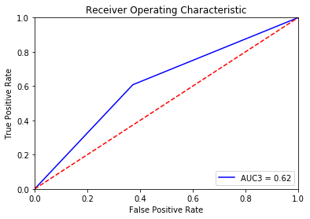

```python
from sklearn import metrics
fpr, tpr, threshold = metrics.roc_curve(y_actu3, y_pred3)
roc_auc3 = metrics.auc(fpr, tpr)


import matplotlib.pyplot as plt
plt.title('Receiver Operating Characteristic')
plt.plot(fpr, tpr, 'b', label = 'AUC3 = %0.2f' % roc_auc3)
AUC3=roc_auc3
plt.legend(loc = 'lower right')
plt.plot([0, 1], [0, 1],'r--')
plt.xlim([0, 1])
plt.ylim([0, 1])
plt.ylabel('True Positive Rate')
plt.xlabel('False Positive Rate')
plt.show()
```

## Feature Importances

```python
model3.feature_importances_
```

```
array([0.0587613 , 0.        , 0.00903839, 0.02146899, 0.03241067,
       0.02742185, 0.00292868, 0.01969477, 0.00195132, 0.02741412,
       0.01551323, 0.02428628, 0.02879409, 0.00970595, 0.02446712,
       0.01703138, 0.05843425, 0.05670689, 0.05745727, 0.06852878,
       0.0604422 , 0.0517137 , 0.05002118, 0.06538123, 0.07211731,
       0.07240647, 0.06590257])
```

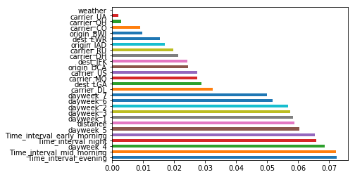

```python
feat_importances3 = pd.Series(model3.feature_importances_, index=Train_Features3[predictors3].columns)
feat_importances3 = feat_importances3.nlargest(28)
feat_importances3.plot(kind='barh')
plt.show()
```

## MODEL 4

### Categorical variables

- Create the dummy variables for the categorical variables
- As the data to build a model should be of integer datatype,we use dummy variables
- After creating dummy variables,we drop the categorical variable columns

```python
categorical_variables=['carrier','dest','origin','dayweek','Time_interval']
for variable in categorical_variables:
#     X[variable].fillna("Missing",inplace=True)
    dummies=pd.get_dummies(DATA_NEW4[variable],prefix=variable)
    DATA_NEW4=pd.concat([DATA_NEW4,dummies],axis=1)
    DATA_NEW4.drop([variable],axis=1,inplace=True)

DATA_NEW4.head()
```

|  | distance | weather | delay | carrier_CO | carrier_DH | carrier_DL | carrier_MQ | carrier_OH | carrier_RU | carrier_UA | ... | dayweek_2 | dayweek_3 | dayweek_4 | dayweek_5 | dayweek_6 | dayweek_7 | Time_interval_early_morning | Time_interval_mid_morning | Time_interval_evening | Time_interval_night |
| --- | --- | --- | --- | --- | --- | --- | --- | --- | --- | --- | --- | --- | --- | --- | --- | --- | --- | --- | --- | --- | --- |
| 2183 | 214 | 0 | 1 | 0 | 0 | 0 | 0 | 0 | 0 | 0 | ... | 0 | 0 | 0 | 0 | 1 | 0 | 1 | 0 | 0 | 0 |
| 1239 | 229 | 0 | 1 | 0 | 0 | 0 | 0 | 0 | 0 | 1 | ... | 0 | 0 | 0 | 0 | 0 | 1 | 0 | 1 | 0 | 0 |
| 770 | 228 | 0 | 1 | 0 | 1 | 0 | 0 | 0 | 0 | 0 | ... | 0 | 0 | 0 | 0 | 0 | 0 | 0 | 0 | 1 | 0 |
| 1021 | 228 | 0 | 1 | 0 | 1 | 0 | 0 | 0 | 0 | 0 | ... | 0 | 0 | 1 | 0 | 0 | 0 | 0 | 1 | 0 | 0 |
| 1144 | 199 | 0 | 1 | 1 | 0 | 0 | 0 | 0 | 0 | 0 | ... | 0 | 0 | 0 | 1 | 0 | 0 | 0 | 0 | 1 | 0 |

5 rows × 28 columns

### Train and Test the data

```python
# Using Skicit-learn to split data into training and testing sets
from sklearn.model_selection import train_test_split
# Split the data into training and testing sets
Train_Features4, Test_Features4, Train_Labels4, Test_Labels4 = train_test_split(DATA_NEW4,DATA_NEW4['delay'],test_size = 0.25, random_state = 42)
```

```python
print('Training Features Shape:',Train_Features4.shape)
print('Training Labels Shape:', Train_Labels4.shape)
print('Testing Features Shape:', Test_Features4.shape)
print('Testing Labels Shape:', Test_Labels4.shape)
```

```
Training Features Shape: (597, 28)
Training Labels Shape: (597,)
Testing Features Shape: (199, 28)
Testing Labels Shape: (199,)
```

```python
def printall(DATA_NEW4,max_rows=10):
    from IPython.display import display,HTML
    display(HTML(DATA_NEW4.to_html(max_rows=max_rows)))

printall(DATA_NEW4.head())
DATA_NEW4.shape
```

[output not shown]

```
(796, 28)
```

```python
predictors4  = [ x for x in Train_Features4.columns if x not in ['delay']]
target4 = 'delay'
```

## Fit the model

```python
model4=RandomForestClassifier(100,oob_score=True,n_jobs=-1,random_state=42)
#Y=X['delay']
model4.fit(Train_Features4[predictors4],Train_Features4[target4])
```

```
RandomForestClassifier(bootstrap=True, class_weight=None, criterion='gini',
            max_depth=None, max_features='auto', max_leaf_nodes=None,
            min_impurity_decrease=0.0, min_impurity_split=None,
            min_samples_leaf=1, min_samples_split=2,
            min_weight_fraction_leaf=0.0, n_estimators=100, n_jobs=-1,
            oob_score=True, random_state=42, verbose=0, warm_start=False)
```

```python
Test_predictors4 = model4.predict(Test_Features4[predictors4])
Test_Features4['Predicted'] = Test_predictors4
Test_Features4[['delay','Predicted']].head()
```

|  | delay | Predicted |
| --- | --- | --- |
| 1706 | 0 | 1 |
| 2064 | 0 | 1 |
| 433 | 1 | 0 |
| 856 | 0 | 1 |
| 390 | 1 | 0 |

## Confusion matrix

```python
y_actu4 = pd.Series(Test_Features4['delay'], name='Actual')
y_pred4 = pd.Series(Test_Features4['Predicted'], name='Predicted')
df_confusion4 = pd.crosstab(y_actu4, y_pred4)
df_confusion4 = pd.crosstab(y_actu4, y_pred4, rownames=['Actual'], colnames=['Predicted'], margins=True)
df_confusion4
```

| Predicted Actual | 0 | 1 | All |
| --- | --- | --- | --- |
| 0 | 61 | 41 | 102 |
| 1 | 30 | 67 | 97 |
| All | 91 | 108 | 199 |

## Accuracy Score

```python
from sklearn.metrics import accuracy_score
AVG4=accuracy_score(y_actu4,y_pred4)
#print('accuracy score:',accuracy_score(y_actu4,y_pred4))
print("accuracy score:",AVG4)
```

```
accuracy score: 0.6432160804020101
```

```python
ROC_AUC4=roc_auc_score(y_actu4, y_pred4, average=None, sample_weight=None)
```

## ROC_AUC Curve

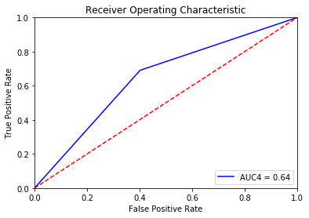

```python
from sklearn import metrics
fpr, tpr, threshold = metrics.roc_curve(y_actu4, y_pred4)
roc_auc4 = metrics.auc(fpr, tpr)


import matplotlib.pyplot as plt
plt.title('Receiver Operating Characteristic')
plt.plot(fpr, tpr, 'b', label = 'AUC4 = %0.2f' % roc_auc4)
AUC4=roc_auc4
plt.legend(loc = 'lower right')
plt.plot([0, 1], [0, 1],'r--')
plt.xlim([0, 1])
plt.ylim([0, 1])
plt.ylabel('True Positive Rate')
plt.xlabel('False Positive Rate')
plt.show()
```

## Feature Importances

```python
model4.feature_importances_
```

```
array([0.06620391, 0.        , 0.01035144, 0.02254518, 0.03221669,
       0.02974504, 0.00276844, 0.02094549, 0.00303311, 0.02855394,
       0.01741844, 0.0296675 , 0.02603178, 0.01596635, 0.02334669,
       0.01709435, 0.04724289, 0.0540769 , 0.05690671, 0.06082943,
       0.05878984, 0.05083883, 0.05293802, 0.06219947, 0.07253737,
       0.0746016 , 0.06315059])
```

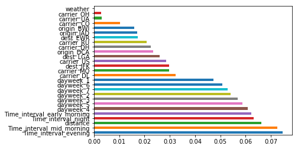

```python
feat_importances4 = pd.Series(model4.feature_importances_, index=Train_Features4[predictors4].columns)
feat_importances4 = feat_importances4.nlargest(28)
feat_importances4.plot(kind='barh')
plt.show()
```

## MODEL 5

### Categorical variables

- Create the dummy variables for the categorical variables
- As the data to build a model should be of integer datatype,we use dummy variables
- After creating dummy variables,we drop the categorical variable columns

```python
categorical_variables=['carrier','dest','origin','dayweek','Time_interval']
for variable in categorical_variables:
#     X[variable].fillna("Missing",inplace=True)
    dummies=pd.get_dummies(DATA_NEW5[variable],prefix=variable)
    DATA_NEW5=pd.concat([DATA_NEW5,dummies],axis=1)
    DATA_NEW5.drop([variable],axis=1,inplace=True)

DATA_NEW5.head()
```

|  | distance | weather | delay | carrier_CO | carrier_DH | carrier_DL | carrier_MQ | carrier_OH | carrier_RU | carrier_UA | ... | dayweek_2 | dayweek_3 | dayweek_4 | dayweek_5 | dayweek_6 | dayweek_7 | Time_interval_early_morning | Time_interval_mid_morning | Time_interval_evening | Time_interval_night |
| --- | --- | --- | --- | --- | --- | --- | --- | --- | --- | --- | --- | --- | --- | --- | --- | --- | --- | --- | --- | --- | --- |
| 1264 | 199 | 0 | 1 | 0 | 0 | 0 | 0 | 0 | 1 | 0 | ... | 0 | 0 | 0 | 0 | 0 | 1 | 0 | 0 | 1 | 0 |
| 1343 | 199 | 0 | 1 | 0 | 0 | 0 | 0 | 0 | 1 | 0 | ... | 0 | 0 | 0 | 0 | 0 | 0 | 0 | 0 | 1 | 0 |
| 965 | 214 | 0 | 1 | 0 | 0 | 0 | 1 | 0 | 0 | 0 | ... | 0 | 1 | 0 | 0 | 0 | 0 | 1 | 0 | 0 | 0 |
| 871 | 214 | 0 | 1 | 0 | 0 | 1 | 0 | 0 | 0 | 0 | ... | 1 | 0 | 0 | 0 | 0 | 0 | 0 | 1 | 0 | 0 |
| 1615 | 228 | 0 | 1 | 0 | 1 | 0 | 0 | 0 | 0 | 0 | ... | 0 | 0 | 0 | 1 | 0 | 0 | 1 | 0 | 0 | 0 |

5 rows × 28 columns

### Train and Test the data

```python
from sklearn.model_selection import train_test_split
# Split the data into training and testing sets
Train_Features5, Test_Features5, Train_Labels5, Test_Labels5 = train_test_split(DATA_NEW5,DATA_NEW5['delay'],test_size = 0.25, random_state = 42)
```

```python
print('Training Features Shape:',Train_Features5.shape)
print('Training Labels Shape:', Train_Labels5.shape)
print('Testing Features Shape:', Test_Features5.shape)
print('Testing Labels Shape:', Test_Labels5.shape)
```

```
Training Features Shape: (597, 28)
Training Labels Shape: (597,)
Testing Features Shape: (199, 28)
Testing Labels Shape: (199,)
```

```python
def printall(DATA_NEW5,max_rows=10):
    from IPython.display import display,HTML
    display(HTML(DATA_NEW5.to_html(max_rows=max_rows)))

printall(DATA_NEW5.head())
DATA_NEW5.shape
```

[output not shown]

```
(796, 28)
```

```python
predictors5  = [ x for x in Train_Features5.columns if x not in ['delay']]
target5 = 'delay'
```

## Fit the model

```python
def model(Y):
    Y=RandomForestClassifier(100,oob_score=True,n_jobs=-1,random_state=42)
#Y=X['delay']
    z=Y.fit(Train_Features5[predictors5],Train_Features5[target5])
    print(z)
model(Y=model5)
```

```
RandomForestClassifier(bootstrap=True, class_weight=None, criterion='gini',
            max_depth=None, max_features='auto', max_leaf_nodes=None,
            min_impurity_decrease=0.0, min_impurity_split=None,
            min_samples_leaf=1, min_samples_split=2,
            min_weight_fraction_leaf=0.0, n_estimators=100, n_jobs=-1,
            oob_score=True, random_state=42, verbose=0, warm_start=False)
```

```python
Test_predictors5 = model5.predict(Test_Features5[predictors5])
Test_Features5['Predicted'] = Test_predictors5
Test_Features5[['delay','Predicted']].head()
```

|  | delay | Predicted |
| --- | --- | --- |
| 1706 | 0 | 1 |
| 2064 | 0 | 0 |
| 634 | 1 | 0 |
| 856 | 0 | 1 |
| 490 | 1 | 1 |

## Confusion Matrix

```python
y_actu5 = pd.Series(Test_Features5['delay'], name='Actual')
y_pred5 = pd.Series(Test_Features5['Predicted'], name='Predicted')
df_confusion5 = pd.crosstab(y_actu5, y_pred5)
df_confusion5 = pd.crosstab(y_actu5, y_pred5, rownames=['Actual'], colnames=['Predicted'], margins=True)
df_confusion5
```

| Predicted Actual | 0 | 1 | All |
| --- | --- | --- | --- |
| 0 | 68 | 34 | 102 |
| 1 | 42 | 55 | 97 |
| All | 110 | 89 | 199 |

## Accuracy score

```python
from sklearn.metrics import accuracy_score
AVG5=accuracy_score(y_actu5,y_pred5)

print('accuracy score:',AVG5)
```

```
accuracy score: 0.6180904522613065
```

```python
ROC_AUC5=roc_auc_score(y_actu5, y_pred5, average=None, sample_weight=None)
```

## ROC_AUC Curve

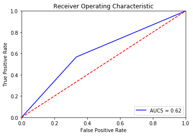

```python
from sklearn import metrics
fpr, tpr, threshold = metrics.roc_curve(y_actu5, y_pred5)
roc_auc5 = metrics.auc(fpr, tpr)


import matplotlib.pyplot as plt
plt.title('Receiver Operating Characteristic')
plt.plot(fpr, tpr, 'b', label = 'AUC5 = %0.2f' % roc_auc5)
AUC5=roc_auc5
plt.legend(loc = 'lower right')
plt.plot([0, 1], [0, 1],'r--')
plt.xlim([0, 1])
plt.ylim([0, 1])
plt.ylabel('True Positive Rate')
plt.xlabel('False Positive Rate')
plt.show()
```

## Feature Importances

```python
model5.feature_importances_
```

```
array([0.05479758, 0.        , 0.00826651, 0.03328377, 0.02774525,
       0.04176886, 0.0053193 , 0.01617477, 0.00517349, 0.04131231,
       0.01451565, 0.02304362, 0.02948498, 0.00849237, 0.01919099,
       0.01796063, 0.05252681, 0.04768971, 0.05687633, 0.06330365,
       0.05470968, 0.06640622, 0.06074523, 0.06195199, 0.07195562,
       0.0634045 , 0.05390018])
```

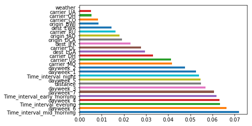

```python
feat_importances5 = pd.Series(model5.feature_importances_, index=Train_Features5[predictors5].columns)
feat_importances5 = feat_importances5.nlargest(28)
feat_importances5.plot(kind='barh')
plt.show()
```

### Accuracy,ROC,AUC values

```python
df=pd.DataFrame({'model':['Model1','Model2','Model3','Model4','Model5'],'Accuracy':[AVG1,AVG2,AVG3,AVG4,AVG5],'ROC Score':[ROC_AUC1,ROC_AUC2,ROC_AUC3,ROC_AUC4,ROC_AUC5],'AUC':[AUC1,AUC2,AUC3,AUC4,AUC5]})
df
```

|  | AUC | Accuracy | ROC Score | model |
| --- | --- | --- | --- | --- |
| 0 | 0.662725 | 0.663317 | 0.662725 | Model1 |
| 1 | 0.566050 | 0.567839 | 0.566050 | Model2 |
| 2 | 0.617849 | 0.618090 | 0.617849 | Model3 |
| 3 | 0.644380 | 0.643216 | 0.644380 | Model4 |
| 4 | 0.616838 | 0.618090 | 0.616838 | Model5 |

## Average Accuracy Score

```python
AVG_AS=(AVG1+AVG2+AVG3+AVG4+AVG5)/5
AVG_AS
```

```
0.6221105527638191
```

```
Average Accuracy Score: 0.6221105527638191
The values of AUC,ROC and Accuracy are observed to be same
```

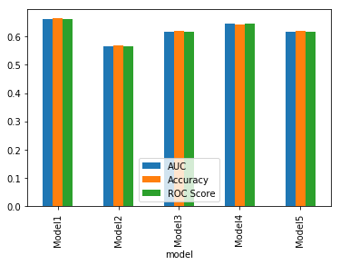

```python
#AVG_AS=(AVG1+AVG2+AVG3+AVG4+AVG5)/5
df.plot(x="model",y=["AUC","Accuracy","ROC Score"],kind='bar')
print("Average Accuracy Score:",AVG_AS)
print("The values of AUC,ROC and Accuracy are observed to be same")
#df.plot()
```